# Exploratory Analysis

Nick Rumbaugh

March 29, 2018

# Milestone Report

The goal of this project is to construct an app to predicts the next word to be typed by a user based on previous ones. In this report, we cover exploratory analysis of the dataset, starting from processing the data and concluding with strategies to simplify our model-building to folow.

## Initial Processing

First, let’s look at some basic information about the dataset. How large are the input files? We can print out the total lines and characters in each:

```bash
wc -l ./data/en_US/en_US.blogs.txt
wc -l ./data/en_US/en_US.news.txt
wc -l ./data/en_US/en_US.twitter.txt
wc -c ./data/en_US/en_US.blogs.txt
wc -c ./data/en_US/en_US.news.txt
wc -c ./data/en_US/en_US.twitter.txt
```

```
## 899288 ./data/en_US/en_US.blogs.txt
## 1010242 ./data/en_US/en_US.news.txt
## 2360148 ./data/en_US/en_US.twitter.txt
## 210160014 ./data/en_US/en_US.blogs.txt
## 205811889 ./data/en_US/en_US.news.txt
## 167105338 ./data/en_US/en_US.twitter.txt
```

The files are 900000 to 2.4 million lines, with around 200 million characters each. The entries in the blogs and news datasets are pretty similar. They have around 230 and 200 characters per entry, respectively. The entries in the Twitter dataset are much shorter, at 70 character per entry, on average, which is somewhat expected, since Tweets were limited to 140 characters maximum.

To look at the content in more detail, we use the *tm* package. Since the files are relatively large, I created subsets of each one with 10000 lines. Since these were randomly chosen, they will be representative of the dataset as a whole.

After loading the contents of this subsetting dataset into a corpus, we perform some transformations to get it into a more useful form. We remove all numbers and punctuation, and put everything into lower case. It may be useful to bring some of these things back for the final model, but they would only obfuscate our exploratory analysis.

```r
vc <- VCorpus(DirSource("/home/rumbaugh/Coursera-Swiftkey/data/en_US/all_10000/"), readerControl = list(language='lat'))
vc <- tm_map(vc, removeNumbers)
vc <- tm_map(vc, removePunctuation)
vc <- tm_map(vc, stripWhitespace)
vc <- tm_map(vc, content_transformer(tolower))
vc_noSW <- tm_map(vc, removeWords, stopwords("english"))
vcDTM <- DocumentTermMatrix(vc)
vc_noSWDTM <- DocumentTermMatrix(vc_noSW)
```

Another transformation commonly used for NLP applications is to remove stopwords, which are very common words like “the”, “and”, or “you”. It’s highly likely we will want to build our model to include these words, so we will branch off the analysis here, with one branch including stopwords and one having them removed. This also allows us to better see the differences between the news, blogs, and Tweets, as well.

We create a document term matrix for the datasets with and without stopwords. These are matrices with one row for each of the three files that went into our analysis, and each column having the frequency that a specific word appears in that file.

## Exploratory Analysis

Using the document term matrices, we can look at how the most common words differ within the dataset. First, let’s look at the 10 most common words, including stopwords:

```r
kable(common_words, caption = 'Most Common Words')
```

Most Common Words

| Rank | Total | count | Blogs | count2 | News | count3 | Twitter | count4 |
| --- | --- | --- | --- | --- | --- | --- | --- | --- |
| 1 | the | 43662 | the | 20181 | the | 19590 | the | 3891 |
| 2 | and | 22564 | and | 11996 | and | 8764 | you | 2392 |
| 3 | that | 9599 | that | 5129 | that | 3494 | and | 1804 |
| 4 | for | 9175 | for | 4042 | for | 3453 | for | 1680 |
| 5 | you | 6648 | you | 3328 | with | 2643 | that | 976 |
| 6 | with | 6509 | with | 3104 | said | 2490 | with | 762 |
| 7 | was | 5866 | was | 3086 | was | 2247 | your | 735 |
| 8 | this | 4673 | this | 2803 | his | 1558 | have | 695 |
| 9 | have | 4520 | have | 2365 | from | 1523 | just | 670 |
| 10 | but | 4205 | but | 2247 | but | 1479 | this | 670 |

All of these words are stopwords, and they are very similar between the different files. There is still some differentiation between them. For example, “you” is one of the most common words in blogs and Tweets, but is not in the top 10 for news, which reflects how news stories rarely use the second person.

There is much more differentiation when looking at the common words with the stopwords removed:

```r
kable(common_words_noSW, caption = 'Most Common Words (No Stopwords)')
```

Most Common Words (No Stopwords)

| Rank | Total | count | Blogs | count2 | News | count3 | Twitter | count4 |
| --- | --- | --- | --- | --- | --- | --- | --- | --- |
| 1 | said | 2942 | one | 1385 | said | 2490 | just | 670 |
| 2 | will | 2681 | will | 1233 | will | 1048 | get | 500 |
| 3 | one | 2593 | just | 1129 | one | 880 | like | 469 |
| 4 | just | 2336 | like | 1123 | new | 669 | love | 456 |
| 5 | like | 2090 | can | 1085 | can | 616 | will | 400 |
| 6 | can | 2066 | time | 950 | two | 583 | now | 397 |
| 7 | time | 1764 | get | 769 | also | 573 | good | 392 |
| 8 | get | 1666 | know | 644 | just | 537 | day | 388 |
| 9 | new | 1579 | now | 621 | year | 525 | dont | 376 |
| 10 | now | 1308 | new | 618 | state | 517 | thanks | 367 |

The news stories tend to focus on words relevant to reporting, like “said” or numbers like “one” or “two”, as well as words pertaining to when and where like “year” and “state”. Tweets seem to focus on words related to more personal interactions or expressing yourself, such as “love”, “good”, “thanks”, and talking about how your “day” went. The common words in the Blog entries seem to be a combination of the qualities of news and Tweets, which could reflect their more personal style compared to news articles, but also the wide range of topics covered.

Rather than look at how often some specific words are used, we can also look at the distribution of how often all words are used.

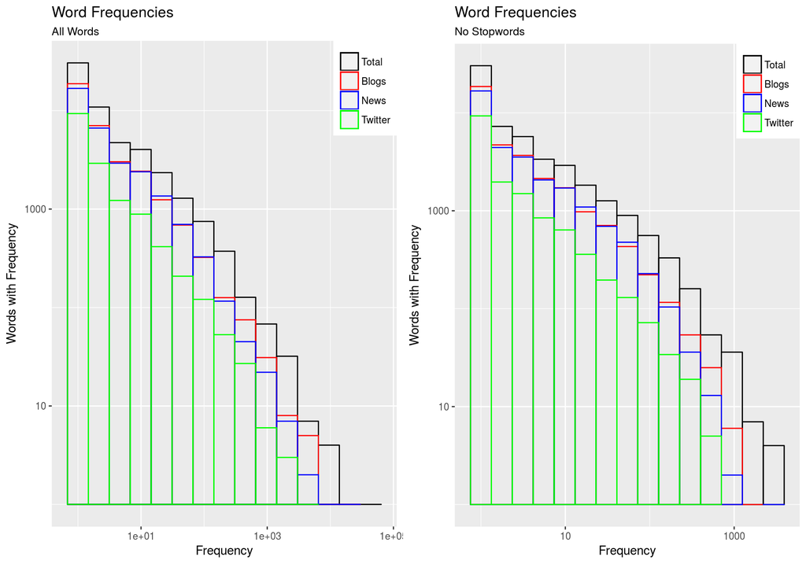

```r
grid.arrange(countshist, counts_noSWhist, ncol=2)
```

### N-grams

An important part of this analysis will be constructing N-grams and predicting the next word in a given N-gram. In our case, an N-gram is an ordered sequence of N words. We will look at the distributions of bigrams (N = 2) and trigrams (N = 3). We will construct new document term matrices for both of these cases, also with and without stopwords.

```r
BigramTokenizer <- function(x) NGramTokenizer(x, Weka_control(min = 2, max = 2))
TrigramTokenizer <- function(x) NGramTokenizer(x, Weka_control(min = 3, max = 3))

vc_bigram_tdm <- DocumentTermMatrix(vc, control = list(tokenize = BigramTokenizer))
vc_trigram_tdm <- DocumentTermMatrix(vc, control = list(tokenize = TrigramTokenizer))
vc_bigram_tdm_noSW <- DocumentTermMatrix(vc_noSW, control = list(tokenize = BigramTokenizer))
vc_trigram_tdm_noSW <- DocumentTermMatrix(vc_noSW, control = list(tokenize = TrigramTokenizer))
```

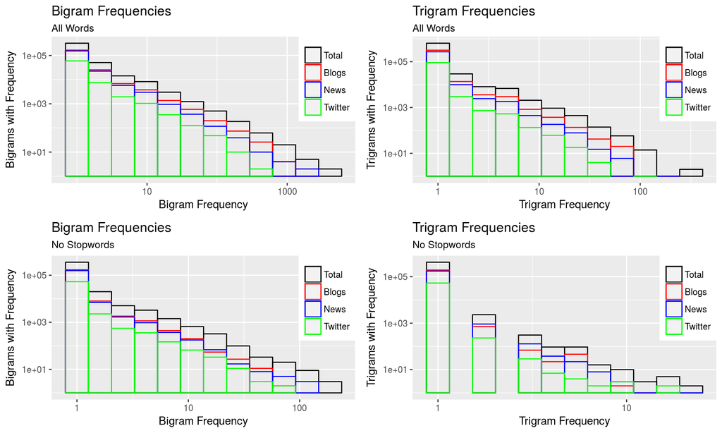

```r
grid.arrange(countsbihist, countstrihist, countsbi_noSWhist, countstri_noSWhist, ncol=2)
```

These plots are constructed in the same way as before, with the x-axis representing the frequency of a given bigram or trigram, and the y-axis showing how many bigrams or trigrams had that frequency within a document. Like the distributions for single words, the frequencies drop off exponentially. Since we are now looking at unique permutations of two or three words, there are a lot fewer compared to single words, which is reflected in only a handful bigrams having frequencies of 1000 or higher, and just a few trigrams having frequencies above 100, when including all words.

However, stopwords have a large effect on N-grams, as there is a marked difference between the top and bottom panels. The high end on the x-axis drops off by an order of magnitude when stopwords are removed. There are now only a few bigrams with frequencies above 100 or trigrams with frequencies above 10. This shows stopwords are imporant for constructing N-grams, and thus for building our models.

## Dictionary Coverage

There are a large number of words that appear only once in our dataset. Many of these will not be particularly useful for constructing our models, and we could more efficiently build those models with a smaller input set of words and N-grams. So, it could be useful to look at how well the top N most common words cover the total size of the dataset.

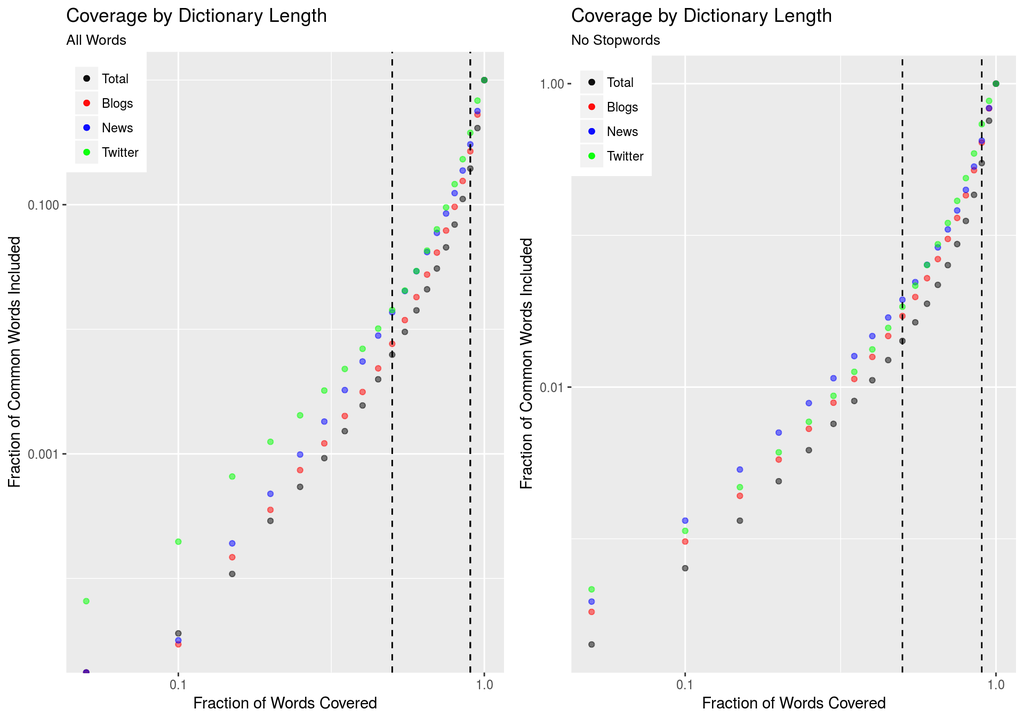

```r
grid.arrange(percplot, percplot_noSW, ncol=2)
```

These plots show how many of the top N most common words you need to include to cover a given percentage of a document. The x-axis is fraction of the document covered. For example, 0.1 on the x-axis means that a dictionary included 10% of the total words in a document (including repeats). The y-axis shows what percentage of words, starting with the most common word and working down, you needed to include in a dictionary to cover that. The axes are shown on logarithmic scales to better show the range. The vertical lines are at 50% and 90% (0.5 and 0.9) on the x-axis.

Looking at the results, the trends are very similar for the different documents, and between the cases with and without stopwords. 50% coverage is achieved using around 1% of the most common words with stopwords included, and a few percent higher when they aren’t. Only around 20% or 30% of the most common words are needed to cover 90% of the total document size with and without including stopwords, respectively.

## Conclusions

Our dataset consists of entries from three sources: blogs, news articles, and Twitter. Looking length of these entries and their most common words, there are a number of differences between them. Tweets are shorter and tend to use more personal language, for example. These differences will complement each other when building a prediction algorithm, since they cover different parts of language. Because the Tweets are shorter overall, it may be necessary to put weights on the different datasets so that they are adequately represented in our models.

We also showed that the analysis can be simplified by filtering the dataset through a dictionary that contains only the most common words. Only the 20% most common words are needed to cover 90% of the total content in the documents. This may be too few to consider, but it does mean we probably don’t have to consider words that appear only a few times in the entire dataset, which would simplify our models considerably.

The next step in this project is to begin constructing models that predict the the next word in an N-gram based on the (N-1)-gram. We have some strategies for simplifying this model construction. I will start building these models using Markov chains, which assign probabilities to the next word in any N-gram based on the (N-1) word before it.